# Evaluating the Effectiveness of Backward Regression, Stepwise Regression, LASSO Regression, and Ridge Regression for Comparative Analysis using a Residential Building Dataset.

Hieu Nguyen

The choice of which regression technique to use depends on the specific characteristics of your data and the goals of your analysis.

**Backward Regression:**

- Use when you have a large number of predictors and want to simplify the model by removing irrelevant variables.
- Start with a model that includes all predictors and iteratively remove variables that are not statistically significant.

**Forward Regression:**

- Employ when you have a small number of predictors and want to build a model by adding variables one at a time.
- Start with an empty model and iteratively add variables that improve model fit or predictive performance.

**Stepwise Regression (combination of forward and backward):**

- Useful when you want to both add and remove predictors from the model.
- Automatically selects variables to add or remove based on statistical criteria, such as p-values or information criteria like AIC or BIC.

**LASSO Regression (Least Absolute Shrinkage and Selection Operator):**

- Appropriate when dealing with high-dimensional data with potentially many irrelevant predictors.
- LASSO performs variable selection and can shrink coefficients toward zero, effectively reducing the number of predictors in the model.
- It’s particularly useful when you suspect that many predictors are weakly related to the response variable.

**Ridge Regression:**

- Suitable when multicollinearity (high correlation between predictors) is a concern.
- Ridge regression adds a penalty term to the regression coefficients, which can help reduce ulticollinearity and provide more stable estimates.
- It’s often used when you want to keep all predictors in the model but reduce their influence.

In practice, the choice between these techniques should also consider factors such as the interpretability of the model, computational resources, and the specific goals of your analysis. You may need to perform cross-validation or other model evaluation techniques to determine which regression method performs best for your particular dataset and objectives.

This notebook will employ the Residential Building Dataset to assess performance using various algorithms.The dataset can be found at https://archive.ics.uci.edu/ml/datasets/Residential+Building+Data+Set.

#### We first analyse the correlation relationship between the variables.

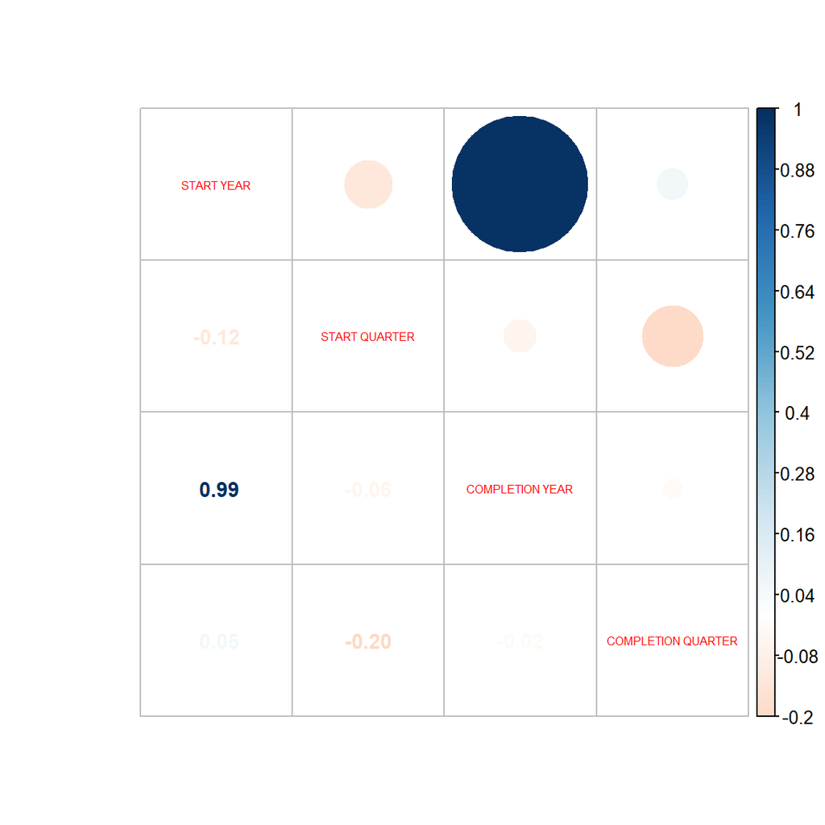

```r
# PROJECT DATES VARIABLES

load("Residen.RData")
dates_variables = Residen[,c(1:4)]
cor_date = cor(dates_variables)
corrplot.mixed(cor_date, is.corr = F, na.label=" ", tl.cex = 0.5, number.cex=0.9)
```

$~$

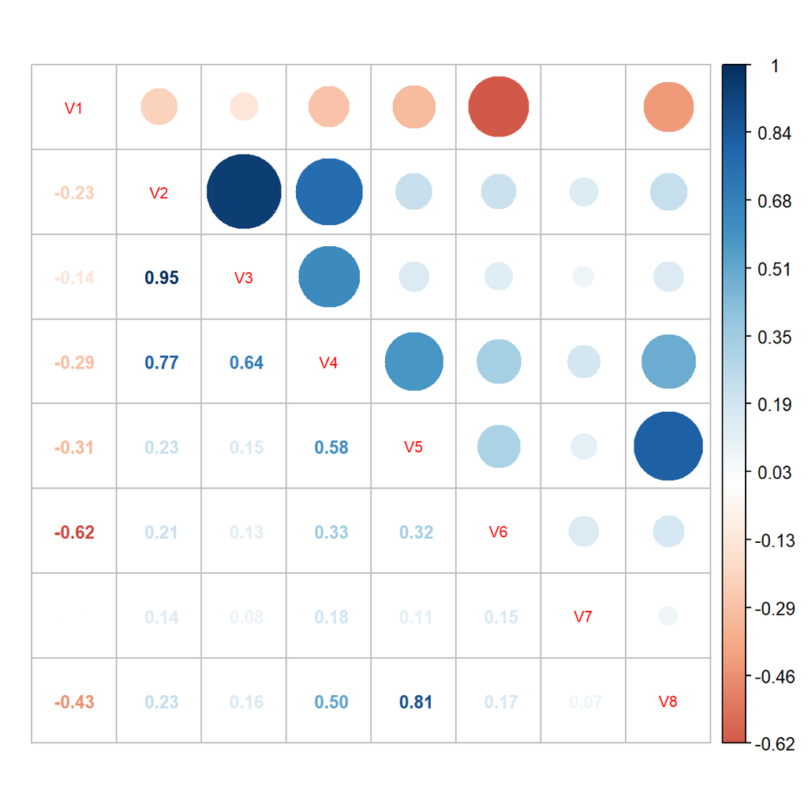

```r
# PHYSICAL AND FINANCIAL VARIABLES

phys_variables = Residen[,c(5:12)]
cor_phys = cor(phys_variables)
corrplot.mixed(cor_phys, is.corr = F, na.label=" ", tl.cex = 0.7, number.cex=0.8)
```

$~$

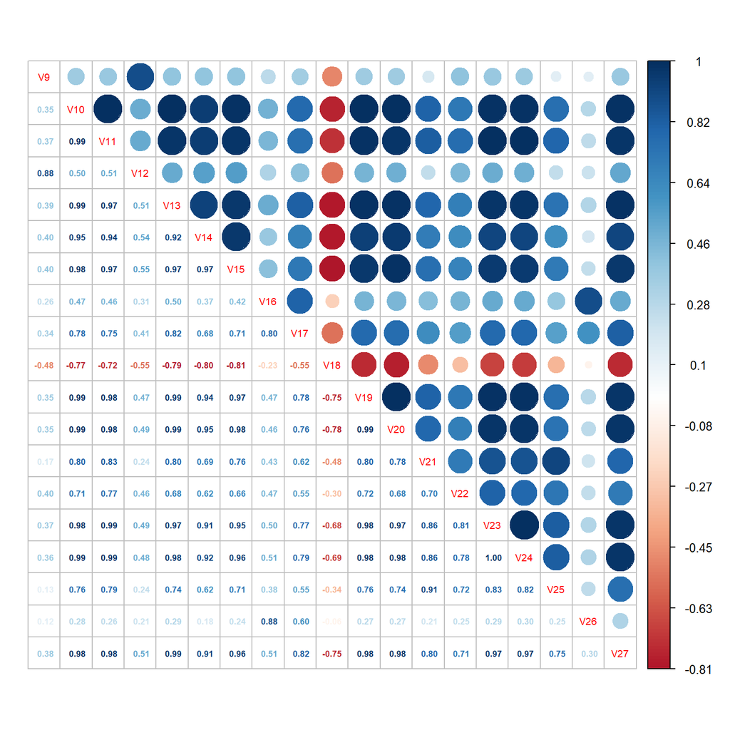

```r
# ECONOMIC VARIABLES LAG1

lag1_variables = Residen[,c(13:31)]
cor_lag1 = cor(lag1_variables)
corrplot.mixed(cor_lag1, is.corr = F, na.label=" ", tl.cex = 0.65, number.cex=0.55)
```

$~$

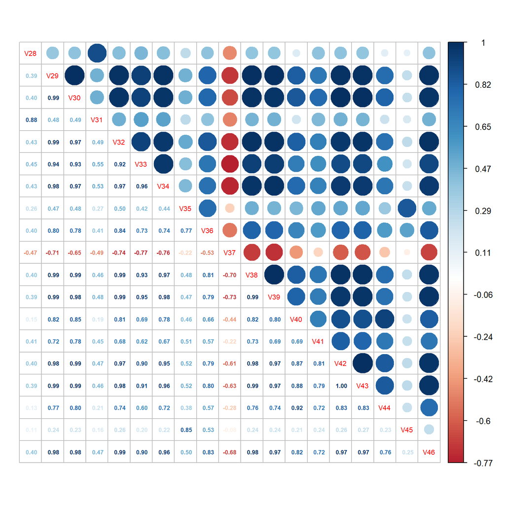

```r
# ECONOMIC VARIABLES LAG2

lag2_variables = Residen[,c(32:50)]
cor_lag2 = cor(lag2_variables)
corrplot.mixed(cor_lag2, is.corr = F, na.label=" ", tl.cex = 0.65, number.cex=0.55)
```

$~$

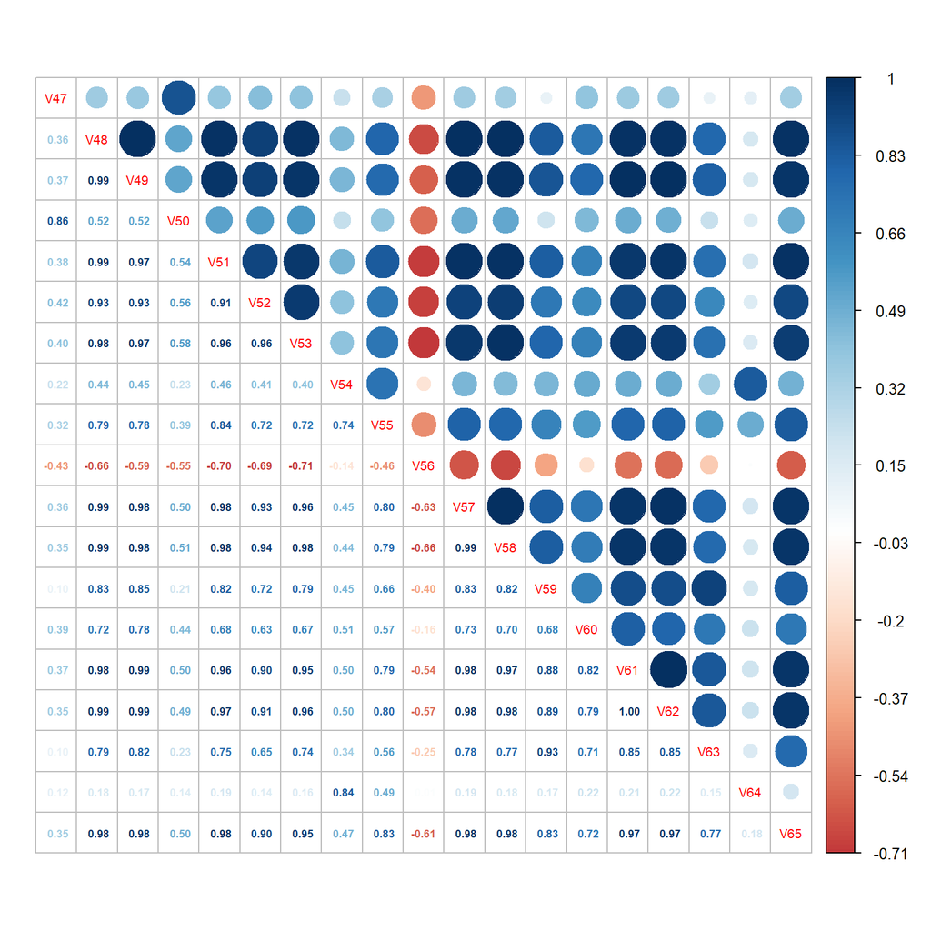

```r
# ECONOMIC VARIABLES LAG3

lag3_variables = Residen[,c(51:69)]
cor_lag3 = cor(lag3_variables)
corrplot.mixed(cor_lag3, is.corr = F, na.label=" ", tl.cex = 0.65, number.cex=0.55)
```

$~$

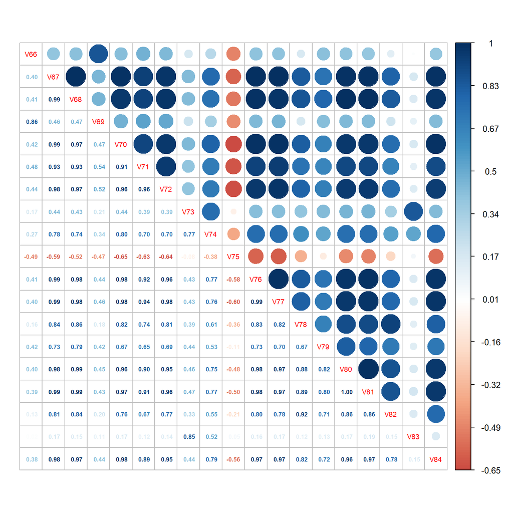

```r
# ECONOMIC VARIABLES LAG4

lag4_variables = Residen[,c(70:88)]
cor_lag4 = cor(lag4_variables)
corrplot.mixed(cor_lag4, is.corr = F, na.label=" ", tl.cex = 0.65, number.cex=0.55)
```

$~$

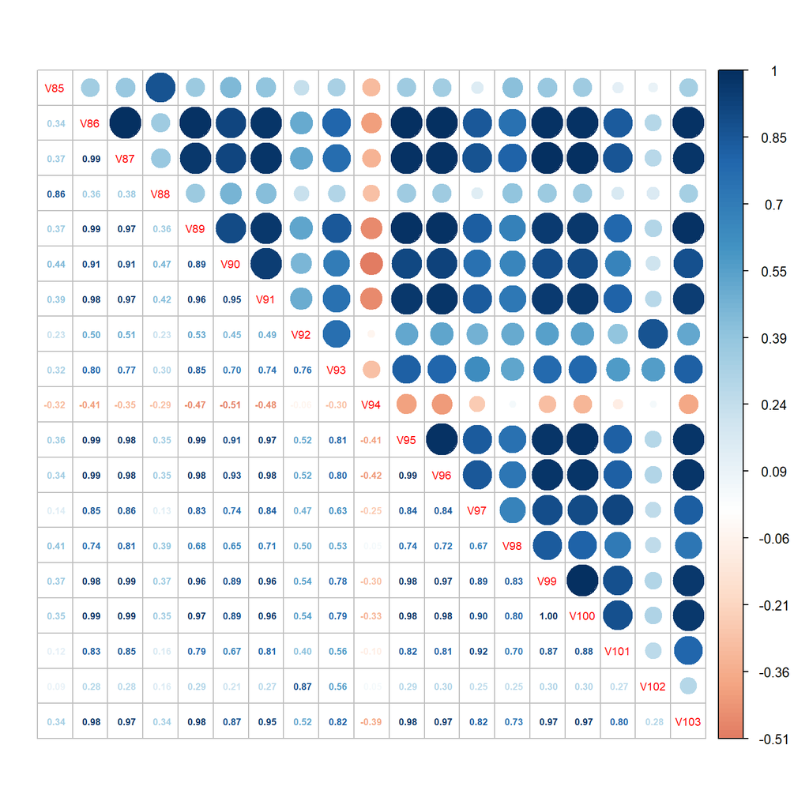

```r
# ECONOMIC VARIABLES LAG5

lag5_variables = Residen[,c(89:107)]
cor_lag5 = cor(lag5_variables)
corrplot.mixed(cor_lag5, is.corr = F, na.label=" ", tl.cex = 0.65, number.cex=0.55)
```

$~$

Graphs shown above show high correlation between many of the variables. Additionally the function below was used to check which variables have correlation above 0.95.

$~$

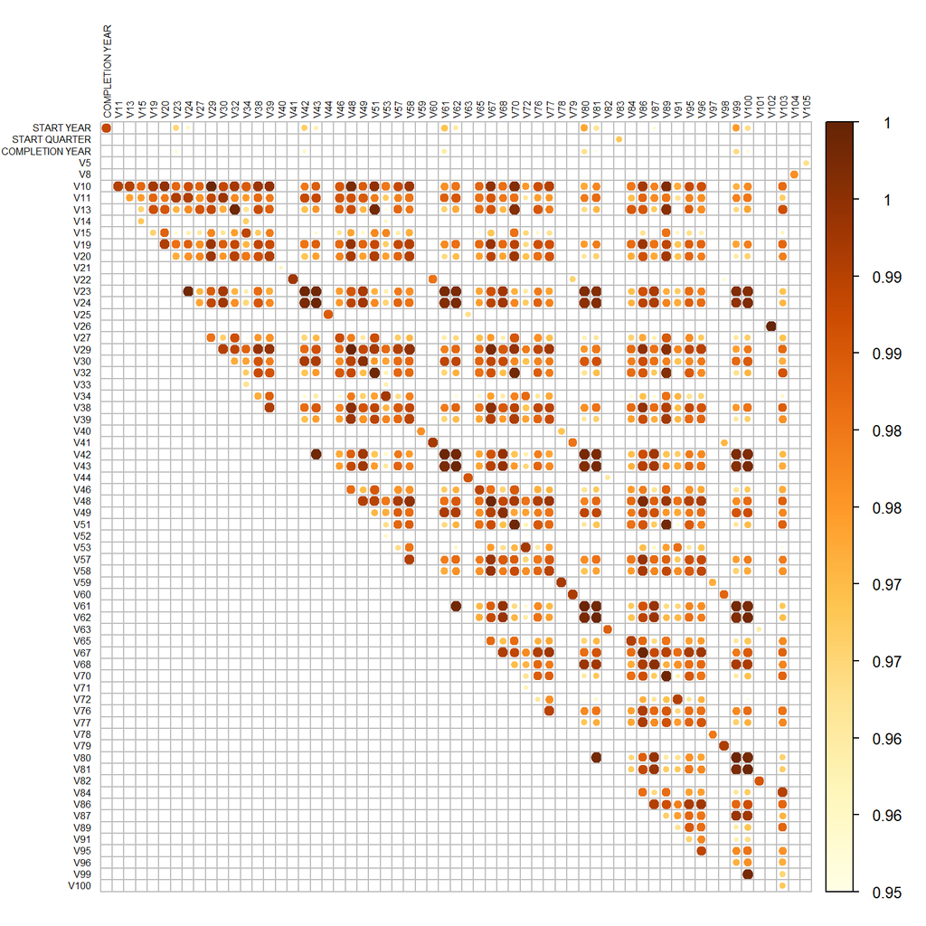

```r
corr_function <- function(data=Residen,sig=0.95){
  corr <- cor(data)
  corr[lower.tri(corr,diag=TRUE)] <- NA   #prepare to drop duplicates and correlations of 1
  corr[corr == 1] <- NA   #drop perfect correlations
  corr <- as.data.frame(as.table(corr))  #turn into a 3-column table
  corr <- na.omit(corr)   #remove the NA values from above
  corr <- subset(corr, abs(Freq) > sig)   #select values above 0.95
  corr <- corr[order(-abs(corr$Freq)),]   #sort by highest correlation
  mtx_corr <- reshape2::acast(corr, Var1~Var2, value.var="Freq")   #turn corr back into matrix in
  #order to plot with corrplot
  corrplot(mtx_corr, is.corr=FALSE, tl.col="black", na.label=" ", tl.cex = 0.5)
  #plot correlations visually
}
corr_function()
```